# Tugas Pertemuan 5 MPDW

Muhamad Farras Surya Dio Putra

2023-10-02

## Library / Packages

```r
library(ggplot2)
library(tsibble)
library(tseries)
library(MASS)
```

```r
library("forecast")
```

```r
library("graphics")
library("TTR")
library("TSA")
```

## Impor Data

```r
library(rio)
dataset = import("https://raw.githubusercontent.com/farrasdp/mpdw/main/Pertemuan%205/dataset%20tugas.csv")
dataset
```

```
##     Periode Returning.Visits
## 1         1              277
## 2         2              462
## 3         3              534
## 4         4              437
## 5         5              261
## 6         6              398
## 7         7              550
## 8         8              597
## 9         9              585
## 10       10              538
## 11       11              477
## 12       12              309
## 13       13              386
## 14       14              588
```

[output cut: 351 more lines]

```r
str(dataset)
```

```
## 'data.frame':    365 obs. of  2 variables:
##  $ Periode         : int  1 2 3 4 5 6 7 8 9 10 ...
##  $ Returning.Visits: int  277 462 534 437 261 398 550 597 585 538 ...
```

```r
dim(dataset)
```

```
## [1] 365   2
```

## Data Penuh

### Time Series

```r
dataset.ts <- ts(dataset$Returning.Visits)
```

Menampilkan ringkasan data

```r
summary(dataset.ts)
```

```
##    Min. 1st Qu.  Median    Mean 3rd Qu.    Max.
##   157.0   395.0   508.0   506.2   617.0   866.0
```

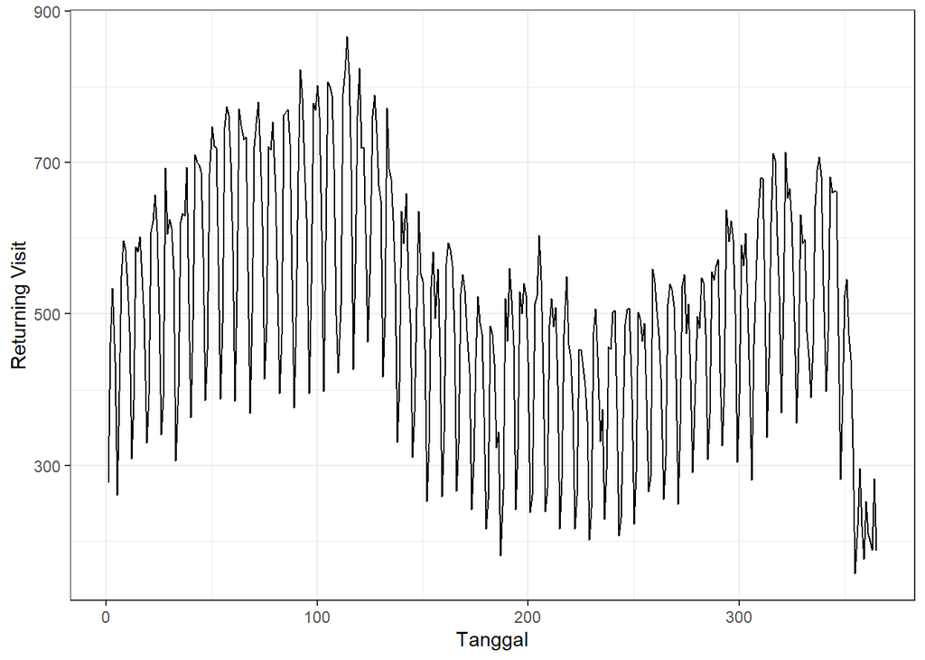

```r
plot_dataset <- dataset.ts |> as_tsibble() |>
  ggplot(aes(x = dataset$Periode, y = dataset$Returning.Visits)) + geom_line() + theme_bw() +
  xlab("Tanggal") + ylab("Returning Visit")
plot_dataset
```

```r
mean(dataset.ts)
```

```
## [1] 506.1808
```

### Plot ACF

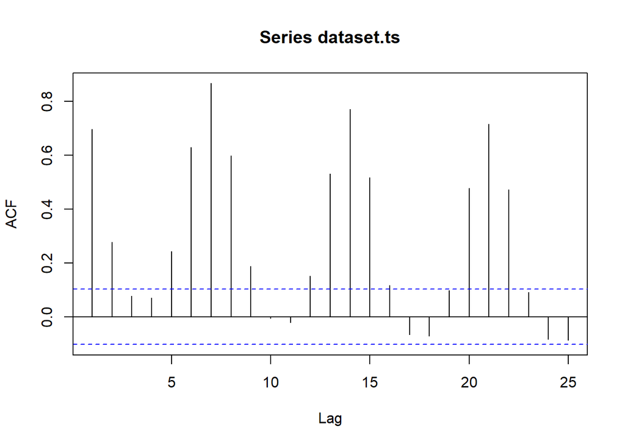

```r
acf(dataset.ts)
```

Berdasarkan plot ACF, terlihat bahwa plot ACF pada data tersebut cenderung *tails off* slowly maka data tersebut terindikasi tidak stasioner

### Uji ADF

```r
tseries::adf.test(dataset.ts)
```

```
##
##  Augmented Dickey-Fuller Test
##
## data:  dataset.ts
## Dickey-Fuller = -1.1664, Lag order = 7, p-value = 0.911
## alternative hypothesis: stationary
```

$H_0$ : Data tidak stasioner dalam rataan

$H_1$ : Data stasioner dalam rataan

Berdasarkan uji ADF tersebut, didapat *p-value* sebesar 0.911 yang lebih besar dari taraf nyata 5% sehingga terima $H_0$ dan menandakan bahwa data tidak stasioner dalam rataan. Hal ini sesuai dengan hasil eksplorasi menggunakan plot time series dan plot ACF.

### Plot Box-Cox

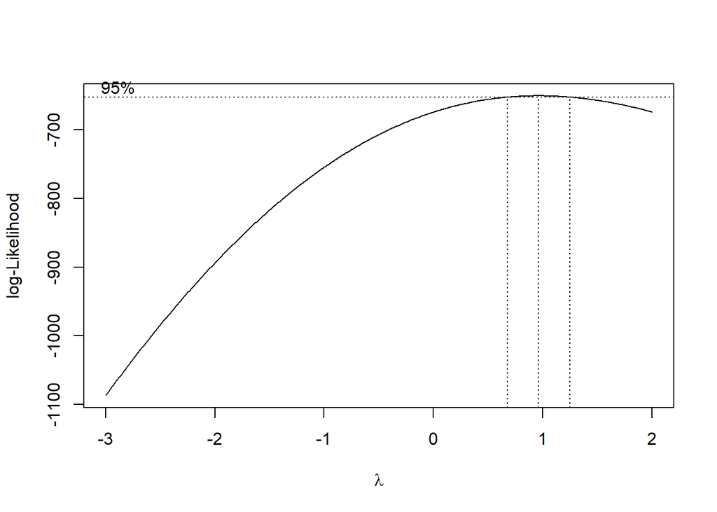

```r
index <- seq(1:365) #sebanyak row data
bc = boxcox(dataset.ts~index, lambda = seq(-3,2,by=0.01))
```

```r
#Nilai Rounded Lambda
lambda <- bc$x[which.max(bc$y)]
lambda
```

```
## [1] 0.96
```

```r
#SK
bc$x[bc$y > max(bc$y) - 1/2 * qchisq(.95,1)]
```

```
##  [1] 0.68 0.69 0.70 0.71 0.72 0.73 0.74 0.75 0.76 0.77 0.78 0.79 0.80 0.81 0.82
## [16] 0.83 0.84 0.85 0.86 0.87 0.88 0.89 0.90 0.91 0.92 0.93 0.94 0.95 0.96 0.97
## [31] 0.98 0.99 1.00 1.01 1.02 1.03 1.04 1.05 1.06 1.07 1.08 1.09 1.10 1.11 1.12
## [46] 1.13 1.14 1.15 1.16 1.17 1.18 1.19 1.20 1.21 1.22 1.23 1.24
```

Gambar di atas menunjukkan nilai *rounded value* ($\lambda$) optimum sebesar **0,96** dan pada selang kepercayaan 95% nilai memiliki batas bawah **0,68** dan batas atas **1,24**. Selang tersebut memuat nilai 1 sehingga dapat dikatakan bahwa data tersebut **stasioner dalam ragam**.

## Partisi Data Part 1

### Time Series

```r
dataset1 <- dataset.ts[1:150]
dataset1
```

```
##   [1] 277 462 534 437 261 398 550 597 585 538 477 309 386 588 582 602 549 495
##  [19] 330 393 608 622 657 609 500 341 390 693 606 625 613 559 306 403 621 633
##  [37] 629 694 514 363 492 710 701 696 687 575 386 452 686 747 722 719 565 388
##  [55] 488 746 774 763 700 584 385 529 771 749 730 734 557 369 501 721 752 780
##  [73] 715 617 414 486 721 716 754 661 528 395 472 763 766 770 725 546 376 496
##  [91] 688 823 785 696 627 395 539 778 769 802 760 610 398 597 806 800 789 692
## [109] 499 422 511 791 821 866 817 691 427 566 762 824 719 720 607 463 552 762
## [127] 789 739 669 650 417 495 772 692 678 624 541 331 410 636 593 659 545 489
## [145] 311 371 509 636 553 543
```

```r
mean(dataset1)
```

```
## [1] 594.9467
```

```r
var(dataset1)
```

```
## [1] 21376.64
```

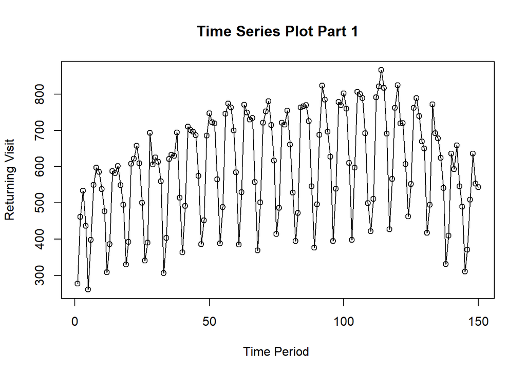

```r
ts.plot(dataset1, xlab="Time Period ", ylab="Returning Visit",
        main = "Time Series Plot Part 1")
points(dataset1)
```

### Plot ACF

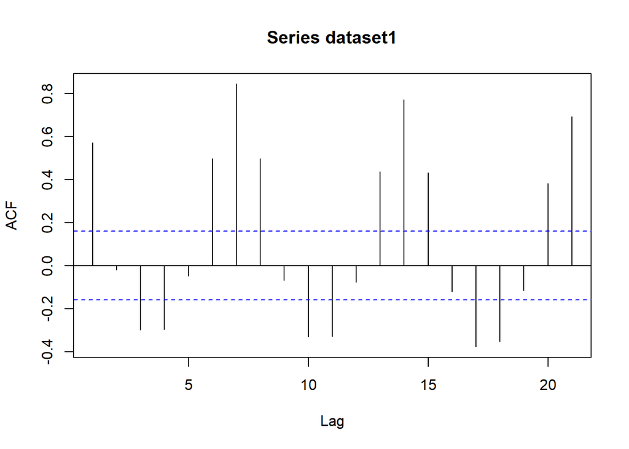

```r
acf(dataset1)
```

Berdasarkan plot ACF, terlihat bahwa plot ACF pada data partisi 1 tersebut cenderung *tails off* slowly maka data tersebut terindikasi tidak stasioner

### Uji ADF

```r
tseries::adf.test(dataset1)
```

```
##
##  Augmented Dickey-Fuller Test
##
## data:  dataset1
## Dickey-Fuller = -1.7936, Lag order = 5, p-value = 0.6624
## alternative hypothesis: stationary
```

$H_0$ : Data tidak stasioner dalam rataan

$H_1$ : Data stasioner dalam rataan

Berdasarkan uji ADF tersebut, didapat *p-value* sebesar 0.6624 yang lebih besar dari taraf nyata 5% sehingga terima $H_0$ dan menandakan bahwa data tidak stasioner dalam rataan. Hal ini sesuai dengan hasil eksplorasi menggunakan plot time series dan plot ACF.

### Plot Box-Cox

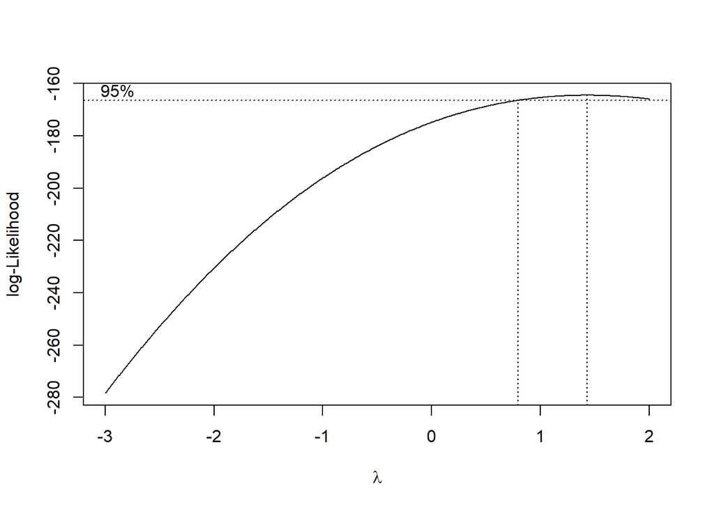

```r
index <- seq(1:150) #sebanyak row data
bc = boxcox(dataset1~index, lambda = seq(-3,2,by=0.01))
```

```r
#Nilai Rounded Lambda
lambda <- bc$x[which.max(bc$y)]
lambda
```

```
## [1] 1.43
```

```r
#SK
bc$x[bc$y > max(bc$y) - 1/2 * qchisq(.95,1)]
```

```
##   [1] 0.80 0.81 0.82 0.83 0.84 0.85 0.86 0.87 0.88 0.89 0.90 0.91 0.92 0.93 0.94
##  [16] 0.95 0.96 0.97 0.98 0.99 1.00 1.01 1.02 1.03 1.04 1.05 1.06 1.07 1.08 1.09
##  [31] 1.10 1.11 1.12 1.13 1.14 1.15 1.16 1.17 1.18 1.19 1.20 1.21 1.22 1.23 1.24
##  [46] 1.25 1.26 1.27 1.28 1.29 1.30 1.31 1.32 1.33 1.34 1.35 1.36 1.37 1.38 1.39
##  [61] 1.40 1.41 1.42 1.43 1.44 1.45 1.46 1.47 1.48 1.49 1.50 1.51 1.52 1.53 1.54
##  [76] 1.55 1.56 1.57 1.58 1.59 1.60 1.61 1.62 1.63 1.64 1.65 1.66 1.67 1.68 1.69
##  [91] 1.70 1.71 1.72 1.73 1.74 1.75 1.76 1.77 1.78 1.79 1.80 1.81 1.82 1.83 1.84
## [106] 1.85 1.86 1.87 1.88 1.89 1.90 1.91 1.92 1.93 1.94 1.95 1.96 1.97 1.98 1.99
## [121] 2.00
```

Gambar di atas menunjukkan nilai *rounded value* ($\lambda$) optimum sebesar **1,43** dan pada selang kepercayaan 95% nilai memiliki batas bawah **0,80** dan batas atas **2,00**. Selang tersebut memuat nilai 1 sehingga dapat dikatakan bahwa data tersebut **stasioner dalam ragam**.

## Partisi Data Part 2

### Time Series

```r
dataset2 <- dataset.ts[1:300]
dataset2
```

```
##   [1] 277 462 534 437 261 398 550 597 585 538 477 309 386 588 582 602 549 495
##  [19] 330 393 608 622 657 609 500 341 390 693 606 625 613 559 306 403 621 633
##  [37] 629 694 514 363 492 710 701 696 687 575 386 452 686 747 722 719 565 388
##  [55] 488 746 774 763 700 584 385 529 771 749 730 734 557 369 501 721 752 780
##  [73] 715 617 414 486 721 716 754 661 528 395 472 763 766 770 725 546 376 496
##  [91] 688 823 785 696 627 395 539 778 769 802 760 610 398 597 806 800 789 692
## [109] 499 422 511 791 821 866 817 691 427 566 762 824 719 720 607 463 552 762
## [127] 789 739 669 650 417 495 772 692 678 624 541 331 410 636 593 659 545 489
## [145] 311 371 509 636 553 543 454 253 329 536 582 494 559 444 259 344 567 594
## [163] 585 564 476 266 328 527 552 531 478 422 242 304 442 523 489 474 364 216
## [181] 254 484 473 435 323 344 181 268 520 464 560 519 460 242 321 529 500 540
## [199] 525 437 238 261 514 524 604 545 422 239 270 486 520 483 509 406 216 283
## [217] 473 549 460 441 373 216 260 453 452 430 404 359 202 244 476 507 444 332
## [235] 374 229 294 457 453 502 505 375 207 231 362 487 506 508 388 223 291 502
## [253] 493 464 488 387 265 285 559 542 504 472 415 255 312 513 539 532 510 415
## [271] 249 354 538 552 474 513 414 291 379 497 481 548 541 473 308 368 556 545
## [289] 563 572 422 326 402 637 596 623 598 500 304 394
```

```r
mean(dataset2)
```

```
## [1] 510.92
```

```r
var(dataset2)
```

```
## [1] 24331.41
```

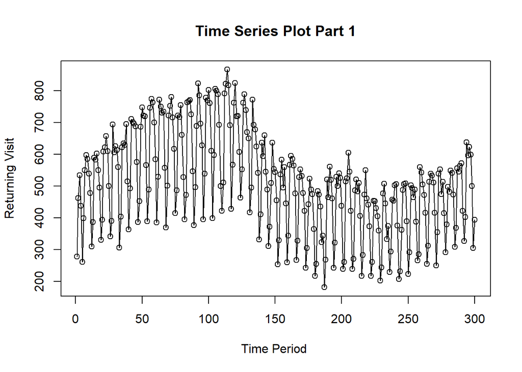

```r
ts.plot(dataset2, xlab="Time Period ", ylab="Returning Visit",
        main = "Time Series Plot Part 1")
points(dataset2)
```

### Plot ACF

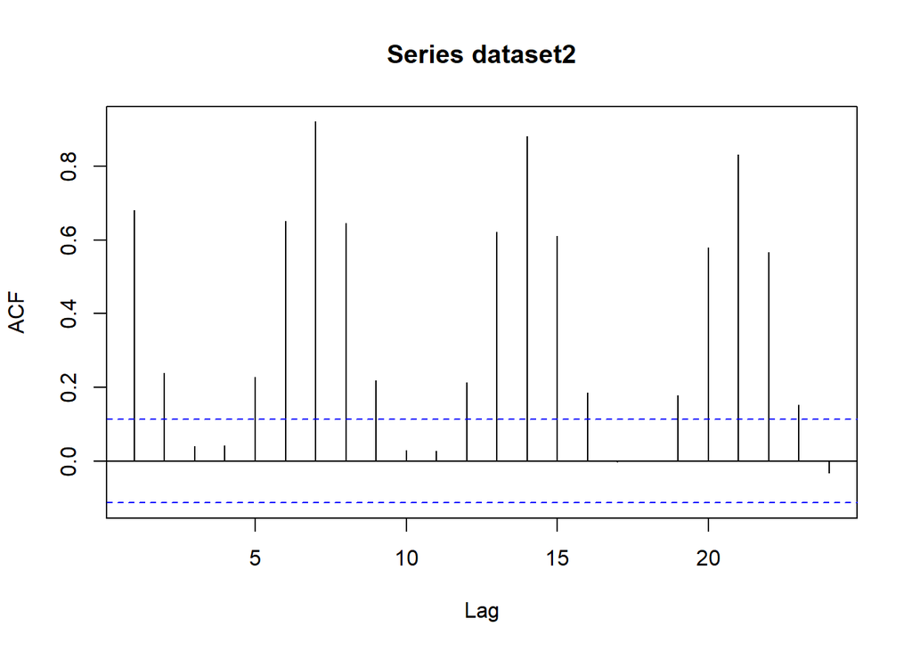

```r
acf(dataset2)
```

Berdasarkan plot ACF, terlihat bahwa plot ACF pada data partisi 2 tersebut cenderung *tails off* slowly maka data tersebut terindikasi tidak stasioner

### Uji ADF

```r
tseries::adf.test(dataset2)
```

```
##
##  Augmented Dickey-Fuller Test
##
## data:  dataset2
## Dickey-Fuller = -2.1031, Lag order = 6, p-value = 0.5328
## alternative hypothesis: stationary
```

$H_0$ : Data tidak stasioner dalam rataan

$H_1$ : Data stasioner dalam rataan

Berdasarkan uji ADF tersebut, didapat *p-value* sebesar 0.5328 yang lebih besar dari taraf nyata 5% sehingga terima $H_0$ dan menandakan bahwa data tidak stasioner dalam rataan. Hal ini sesuai dengan hasil eksplorasi menggunakan plot time series dan plot ACF.

### Plot Box-Cox

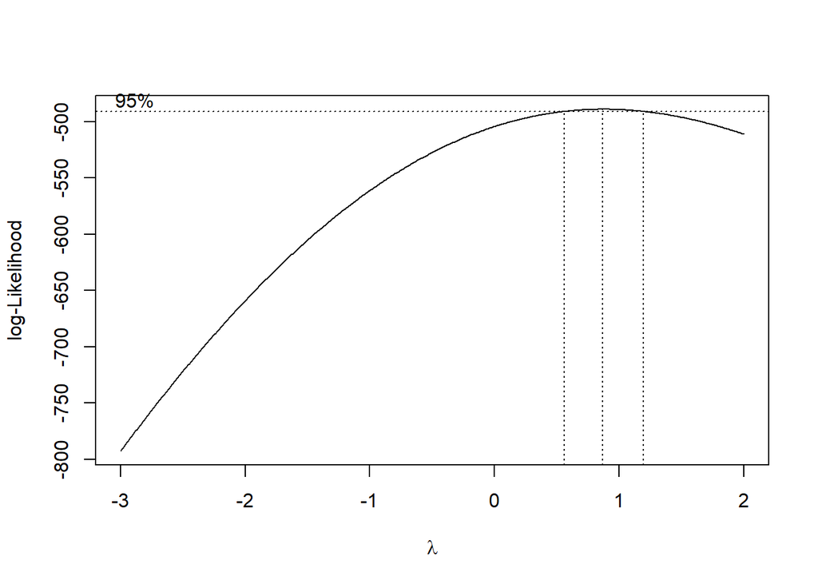

```r
index <- seq(1:300) #sebanyak row data
bc = boxcox(dataset2~index, lambda = seq(-3,2,by=0.01))
```

```r
#Nilai Rounded Lambda
lambda <- bc$x[which.max(bc$y)]
lambda
```

```
## [1] 0.87
```

```r
#SK
bc$x[bc$y > max(bc$y) - 1/2 * qchisq(.95,1)]
```

```
##  [1] 0.56 0.57 0.58 0.59 0.60 0.61 0.62 0.63 0.64 0.65 0.66 0.67 0.68 0.69 0.70
## [16] 0.71 0.72 0.73 0.74 0.75 0.76 0.77 0.78 0.79 0.80 0.81 0.82 0.83 0.84 0.85
## [31] 0.86 0.87 0.88 0.89 0.90 0.91 0.92 0.93 0.94 0.95 0.96 0.97 0.98 0.99 1.00
## [46] 1.01 1.02 1.03 1.04 1.05 1.06 1.07 1.08 1.09 1.10 1.11 1.12 1.13 1.14 1.15
## [61] 1.16 1.17 1.18 1.19
```

Gambar di atas menunjukkan nilai *rounded value* ($\lambda$) optimum sebesar **0,87** dan pada selang kepercayaan 95% nilai memiliki batas bawah **0,56** dan batas atas **1,19**. Selang tersebut memuat nilai 1 sehingga dapat dikatakan bahwa data tersebut **stasioner dalam ragam**.